# Analisi dataset ‘cardekho’

Gruppo F

30/6/2022

# Introduzione al dataset

Il dataset in analisi, *“Car details v3.csv”*, è un file csv (comma separated values) scaricato da “https://www.kaggle.com/datasets/nehalbirla/vehicle-dataset-from-cardekho”. La documentazione del dataset ci informa che esso contiene valori ottenuti tramite **web-scraping**, pertanto ci aspettiamo potenziali problemi su forma e correttezza dei dati. Importiamo il file per svolegere le prime **analisi esplorative**, poi osserviamo le prime colonne ed il loro contenuto:

| name | year | selling_price | km_driven | fuel | seller_type | transmission | owner | mileage | engine | max_power | torque | seats |
| --- | --- | --- | --- | --- | --- | --- | --- | --- | --- | --- | --- | --- |
| Maruti Swift Dzire VDI | 2014 | 450000 | 145500 | Diesel | Individual | Manual | First Owner | 23.4 kmpl | 1248 CC | 74 bhp | 190Nm@ 2000rpm | 5 |
| Skoda Rapid 1.5 TDI Ambition | 2014 | 370000 | 120000 | Diesel | Individual | Manual | Second Owner | 21.14 kmpl | 1498 CC | 103.52 bhp | 250Nm@ 1500-2500rpm | 5 |
| Honda City 2017-2020 EXi | 2006 | 158000 | 140000 | Petrol | Individual | Manual | Third Owner | 17.7 kmpl | 1497 CC | 78 bhp | 12.7@ 2,700(kgm@ rpm) | 5 |

Struttura dei dati:

```r
str(carsCSV)
```

```
## 'data.frame':    8128 obs. of  13 variables:
##  $ name         : chr  "Maruti Swift Dzire VDI" "Skoda Rapid 1.5 TDI Ambition" "Honda City 2017-2020 EXi" "Hyundai i20 Sportz Diesel" ...
##  $ year         : int  2014 2014 2006 2010 2007 2017 2007 2001 2011 2013 ...
##  $ selling_price: int  450000 370000 158000 225000 130000 440000 96000 45000 350000 200000 ...
##  $ km_driven    : int  145500 120000 140000 127000 120000 45000 175000 5000 90000 169000 ...
##  $ fuel         : chr  "Diesel" "Diesel" "Petrol" "Diesel" ...
##  $ seller_type  : chr  "Individual" "Individual" "Individual" "Individual" ...
##  $ transmission : chr  "Manual" "Manual" "Manual" "Manual" ...
##  $ owner        : chr  "First Owner" "Second Owner" "Third Owner" "First Owner" ...
##  $ mileage      : chr  "23.4 kmpl" "21.14 kmpl" "17.7 kmpl" "23.0 kmpl" ...
##  $ engine       : chr  "1248 CC" "1498 CC" "1497 CC" "1396 CC" ...
##  $ max_power    : chr  "74 bhp" "103.52 bhp" "78 bhp" "90 bhp" ...
##  $ torque       : chr  "190Nm@ 2000rpm" "250Nm@ 1500-2500rpm" "12.7@ 2,700(kgm@ rpm)" "22.4 kgm at 1750-2750rpm" ...
##  $ seats        : int  5 5 5 5 5 5 5 4 5 5 ...
```

In merito alle 13 variabili, notiamo subito che:

**“name”** contiene due valori utili, la marca dell’auto (fattorizzabile) ed il modello specifico.

**“selling_price”** è in Rupie Indiane (INR), confermato dalla documentazione del Dataset.

**“mileage”** ha diverse unità di misura (in relazione a “fuel”)

**“torque”** contiene sia i valori di coppia sia i giri motore in cui tale coppia viene sviluppata, ma raccolti in modo estremamente eterogeneo.

È pertanto necessaria una estensiva pulizia dei dati, generiamo pertanto il data frame “cleanedCSV”:

# Pulizia dei dati

```r
if (! file.exists("cleanedCSV.csv")) {
  source("clean_csv.R") #pulizia delle singole variabili e creazione di cleanedCSV.csv
  rm(list=ls())
}
#import e fattorizzazione del nuovo file
cleanedCSV <- read.csv("cleanedCSV.csv", header=TRUE)
cleanedCSV$brand <- factor(cleanedCSV$brand)
cleanedCSV$fuel <- factor(cleanedCSV$fuel)
cleanedCSV$seller_type <- factor(cleanedCSV$seller_type)
cleanedCSV$transmission <- factor(cleanedCSV$transmission)
cleanedCSV$owner <- factor(cleanedCSV$owner)
cleanedCSV$owner <- factor( # ordinamento dei livelli
  cleanedCSV$owner, levels=c(
    "First Owner", "Second Owner", "Third Owner", "Fourth & Above Owner", "Test Drive Car")
)
cleanedCSV$seats <- factor(cleanedCSV$seats)
cleanedNA <- na.omit(cleanedCSV) #creazione in memoria del DF di lavoro, senza i valori NA.
```

*seguono degli estratti significativi del processo di pulizia:*

**“name”**: sempre nel formato “car_brand model”, dove car_brand è fattorizzabile: estratta la prima sottostringa (brand), salvata in una colonna a parte e poi sottratta dal name originale;

**“selling_price”**: la differente valuta rende meno immediata la lettura dei grafici, pertanto abbiamo convertito i prezzi in EUR al cambio del 2020 (1 INR = 0.0118 EUR);

**“mileage”**: rimossa l’unità di misura, facilmente ricavabile da “fuel”: km/l per benzina e diesel, km/kg per GPL e metano;

**“engine”**: qui è stata svolta una trasformazione dei dati, la cilindrata è stata arrotondata ai valori di marketing: ai fini della ricerca su trend di mercato la differenza tra un motore 1297CC ed un 1298CC non è rilevante, sono entrambe classificate e vendute come “1.3”;

**“max_power”**: rimossa l’unità di misura (tutte omogenee);

**“brand”, “fuel”, “seller_type”, “transmission”, “owner”, “seats”**: fattorizzate così com’erano;

**“torque”**: la più eterogenea, espressa in più di 40 modi diversi. Le stringhe sono state manipolate tramite rimozioni successive dei caratteri inutili tramite gsub, sub e l’uso di regexpr. Successivamente è stata uniformata la unità di misura convertendo tutti i valori presenti in kg/m in Nm (la più frequente). Nel caso di UdM non specificata giudicando l’ordine di grandezza dei valori è stato scelto il Nm. In caso fossero presenti entrambe, è stato scelto il Nm per uniformità.

*nota bene: tutte le variabili sono state controllate, uniformando eventuali stringhe vuote e valori mancanti con NA.*

```r
   unique(gsub('[[:digit:]]','_' ,carsCSV$torque)) #modi in cui è espresso "torque" nel csv originale:
```

```
##  [1] "___Nm@ ____rpm"              "___Nm@ ____-____rpm"
##  [3] "__._@ _,___(kgm@ rpm)"       "__._ kgm at ____-____rpm"
##  [5] "___.__nm@ ____rpm"           "_._@ _,___(kgm@ rpm)"
##  [7] "__Nm@ ____rpm"               ""
##  [9] "___._Nm@ ____-____rpm"       "___._Nm@ ____rpm"
## [11] "_._kgm@ ____rpm"             "__.__Nm@ ____rpm"
## [13] "___Nm@ ____~____rpm"         "__ Nm at ____ rpm"
## [15] "__._Nm@ ____rpm"             "___nm@ ____-____rpm"
## [17] "___@ ____-____rpm"           "___Nm"
## [19] "___ Nm at ____ rpm"          "__Nm@ ____-____rpm"
## [21] "__._kgm@ ____rpm"            "___Nm at ____ rpm"
## [23] "__._ KGM at ____ RPM"        "___nm@ ____rpm"
## [25] "__._ kgm at _,___ rpm"       "___.__nm@ ____-____rpm"
## [27] "__._@ ____-____(kgm@ rpm)"   "___ Nm at ____-____rpm"
## [29] "___.__Nm@ ____rpm"           "__@ _,___-_,___(kgm@ rpm)"
```

[output cut: 17 more lines]

**Il dataframe pulito:**

| brand | car_type | year | selling_price | km_driven | fuel | seller_type | transmission | owner | mileage | engine | max_power | seats | torque | rpm |
| --- | --- | --- | --- | --- | --- | --- | --- | --- | --- | --- | --- | --- | --- | --- |
| Maruti | Swift Dzire VDI | 2014 | 5310.0 | 145500 | Diesel | Individual | Manual | First Owner | 23.40 | 1200 | 74.00 | 5 | 190.000 | 2000 |
| Skoda | Rapid 1.5 TDI Ambition | 2014 | 4366.0 | 120000 | Diesel | Individual | Manual | Second Owner | 21.14 | 1500 | 103.52 | 5 | 250.000 | 1500 |
| Honda | City 2017-2020 EXi | 2006 | 1864.4 | 140000 | Petrol | Individual | Manual | Third Owner | 17.70 | 1500 | 78.00 | 5 | 124.587 | 2700 |

# Analisi esplorativa

#### **“brand”**

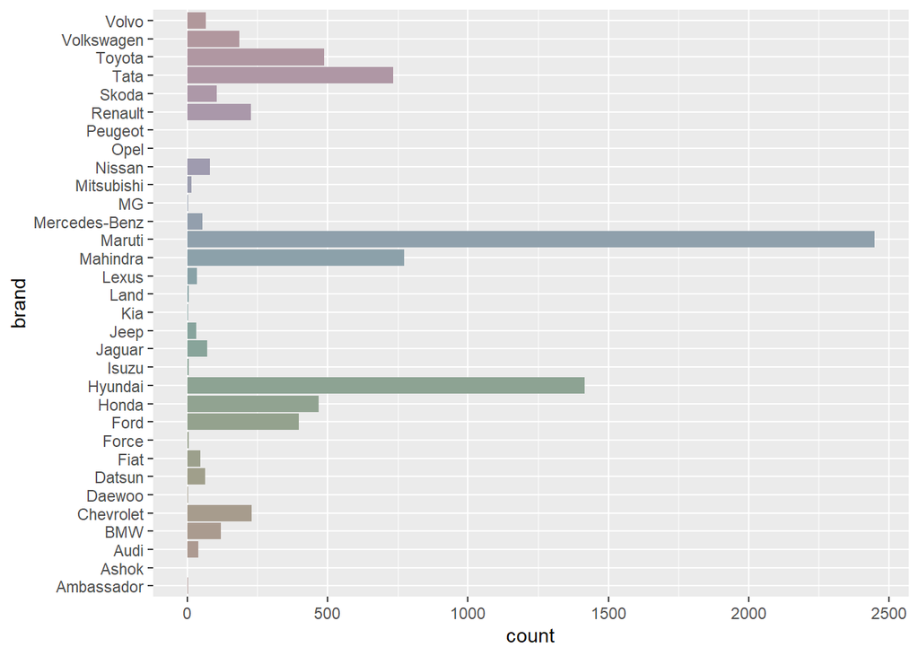

```
##
##        Maruti       Hyundai      Mahindra          Tata        Toyota
##   30.11811024   17.40895669    9.49803150    9.03051181    6.00393701
##         Honda          Ford     Chevrolet       Renault    Volkswagen
##    5.74557087    4.88435039    2.82972441    2.80511811    2.28838583
##           BMW         Skoda        Nissan        Jaguar         Volvo
##    1.47637795    1.29183071    0.99655512    0.87352362    0.82431102
##        Datsun Mercedes-Benz          Fiat          Audi         Lexus
##    0.79970472    0.66437008    0.57824803    0.49212598    0.41830709
##          Jeep    Mitsubishi         Force          Land         Isuzu
##    0.38139764    0.17224409    0.07381890    0.07381890    0.06151575
##    Ambassador           Kia        Daewoo            MG         Ashok
##    0.04921260    0.04921260    0.03690945    0.03690945    0.01230315
##          Opel       Peugeot
##    0.01230315    0.01230315
```

Il mercato osservato è dominato da tre brand principali: **“Maruti”**, **“Hyundai”** e **“Mahindra”**, che insieme superano il 50% delle auto in vendita.

#### **“owner”**

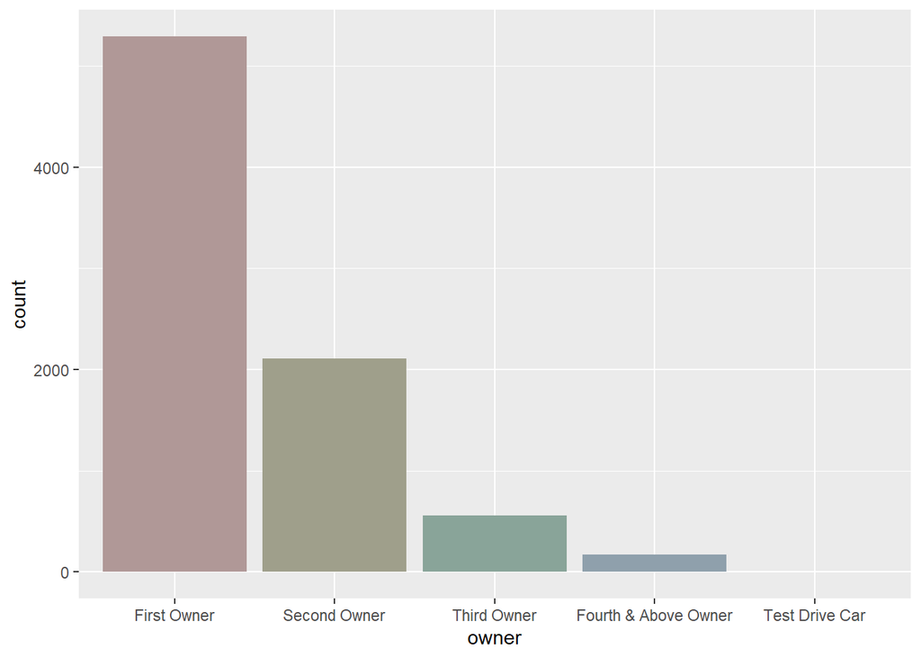

```
##
##          First Owner         Second Owner          Third Owner
##          65.07135827          25.89812992           6.82824803
## Fourth & Above Owner       Test Drive Car
##           2.14074803           0.06151575
```

La maggior parte (~65%) delle auto nel campione sono vendute come seconda mano (l’inserzione è stata creata dal “First Owner”)

#### **“fuel”**

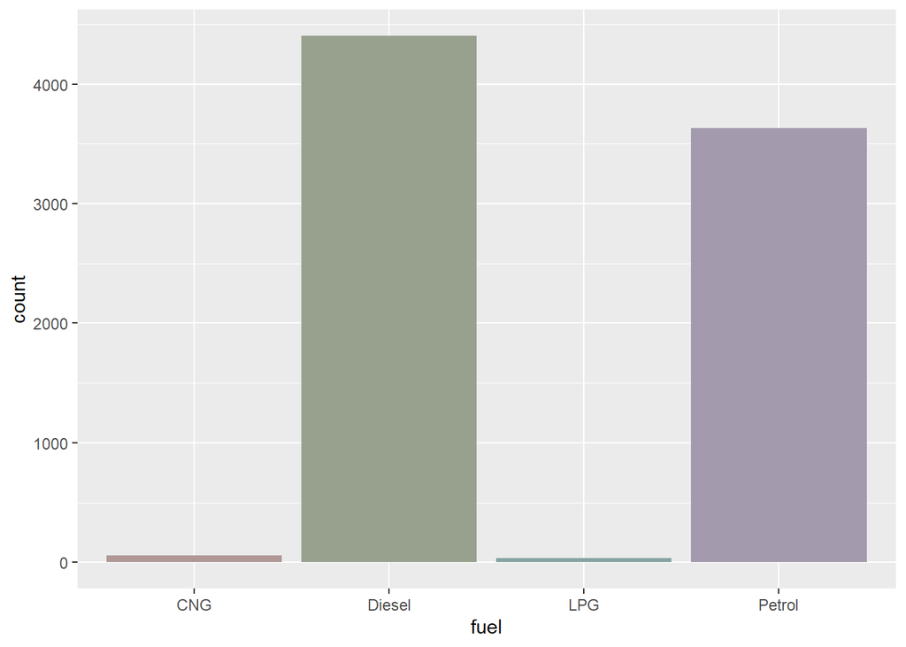

```
##
##        CNG     Diesel        LPG     Petrol
##  0.7012795 54.1584646  0.4675197 44.6727362
```

La quantità di auto a GPL o Gas Naturale presenti sulla piattaforma è estremamente ridotta, hanno una presenza combinata minore del 1,2% (<100 modelli)

#### **“seller_type”**

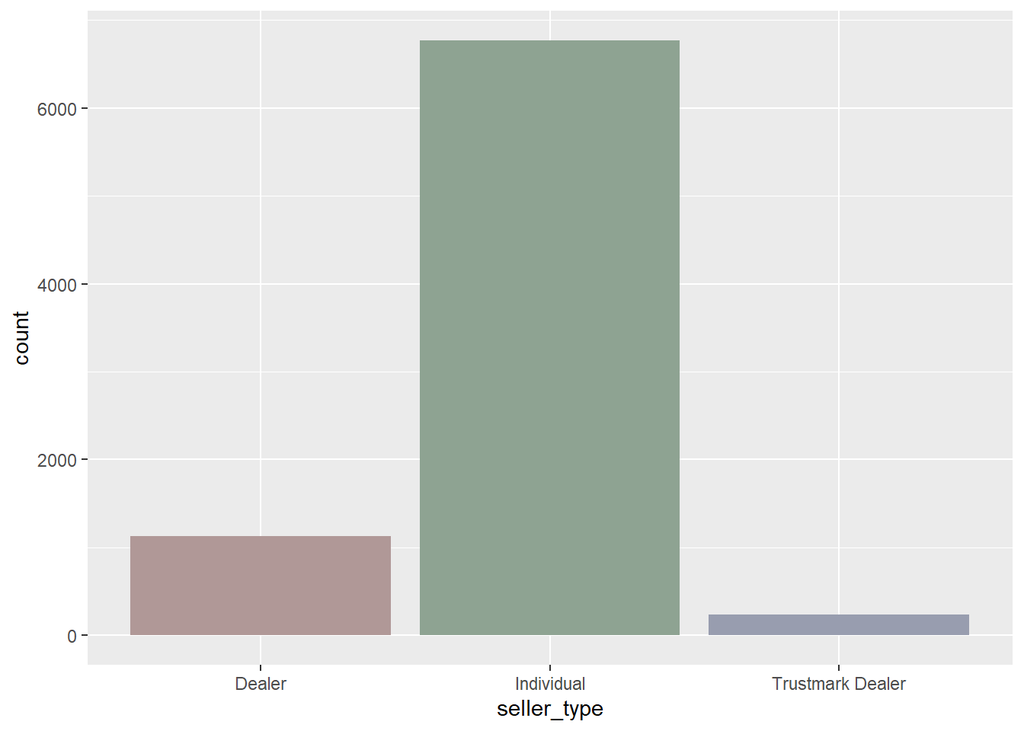

```
##
##           Dealer       Individual Trustmark Dealer
##        13.853346        83.243110         2.903543
```

La maggior parte degli utenti della piattaforma (>83%) sono privati, il ~14% sono concessionarie mentre le piattaforme di usato certificato sono inferiori al 3%.

#### **“year”**

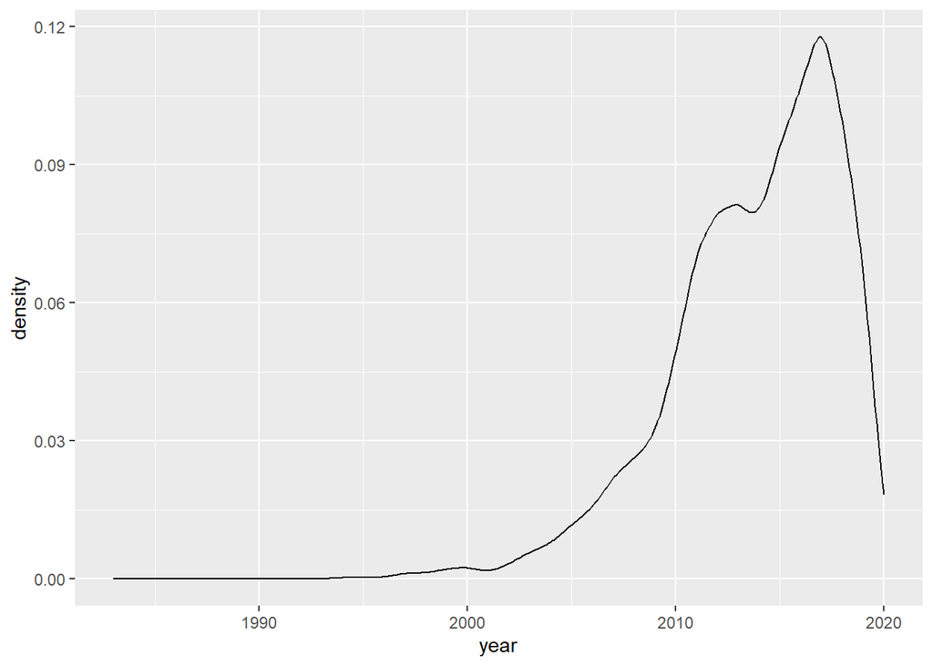

```
##
##        1983        1991        1994        1995        1996        1997
##  0.01230315  0.01230315  0.03690945  0.02460630  0.03690945  0.13533465
##        1998        1999        2000        2001        2002        2003
##  0.12303150  0.22145669  0.27066929  0.12303150  0.33218504  0.60285433
##        2004        2005        2006        2007        2008        2009
##  0.76279528  1.19340551  1.52559055  2.25147638  2.63287402  3.02657480
##        2010        2011        2012        2013        2014        2015
##  4.84744094  7.28346457  8.00935039  8.24311024  7.64025591  9.54724409
##        2016        2017        2018        2019        2020
## 10.56840551 12.52460630  9.92864173  7.17273622  0.91043307
```

Il dataset è del 2020, quindi lo ~0,9% di densità delle auto del 2020 è giustificato. Dalla distribuzione così asimmetrica verso destra possiamo supporre che gli utenti di questo servizio di vendita siano più interessati a vender auto moderne rispetto alle auto d’epoca, infatti il picco di auto vendute (~12.5%) è nel 2017, ergo molto recenti.

# Confronto con modello teorico

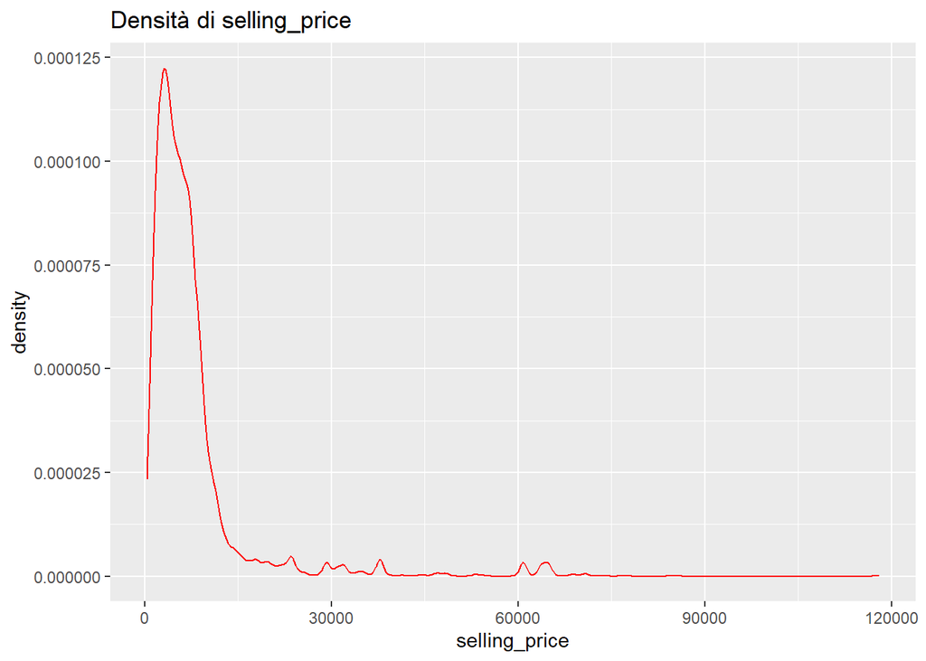

Decidiamo di applicare la funzione log10 sui valori di selling_price per concentrare l’analisi sulle fasce di prezzo.

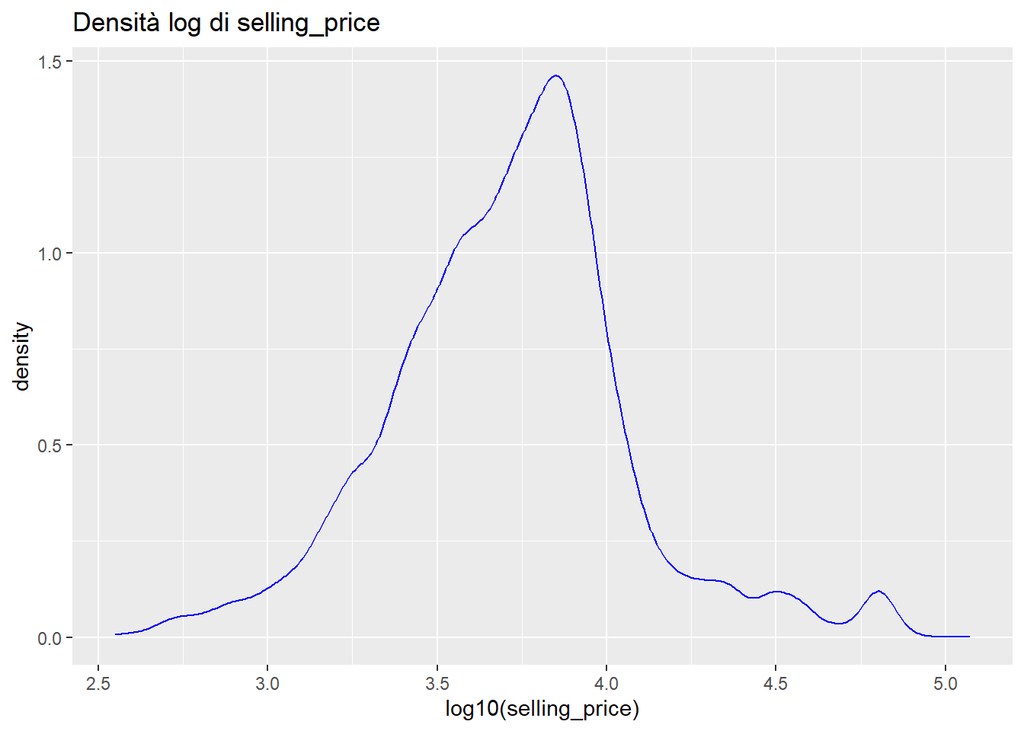

vista la forma a campana, proviamo a confrontare la variabile “selling_price” in scala logaritmica con un il modello teorico della Gaussiana.

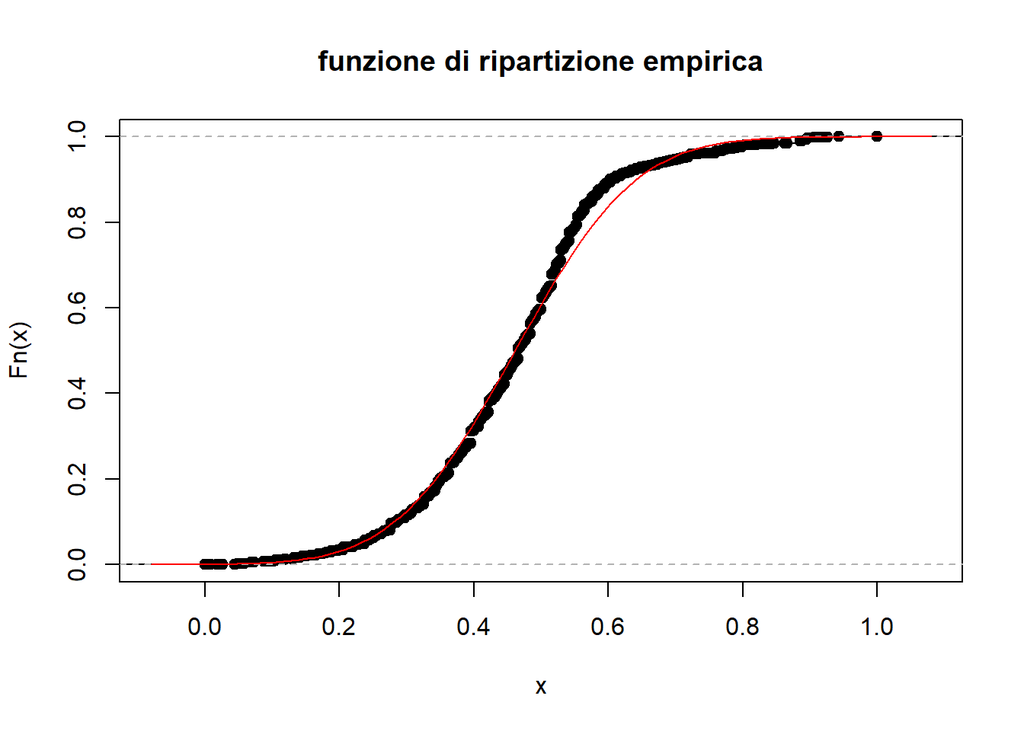

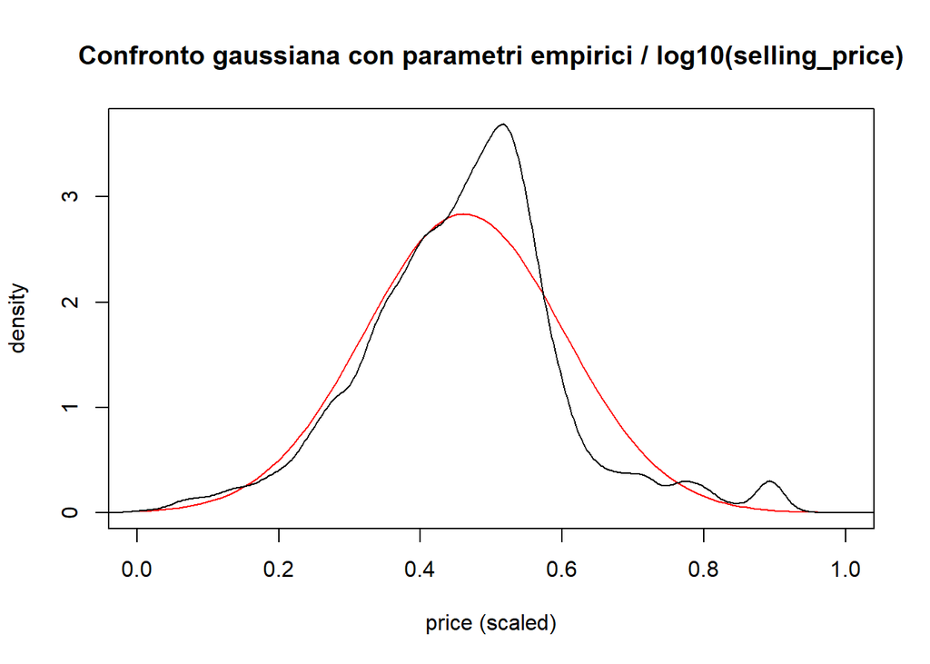

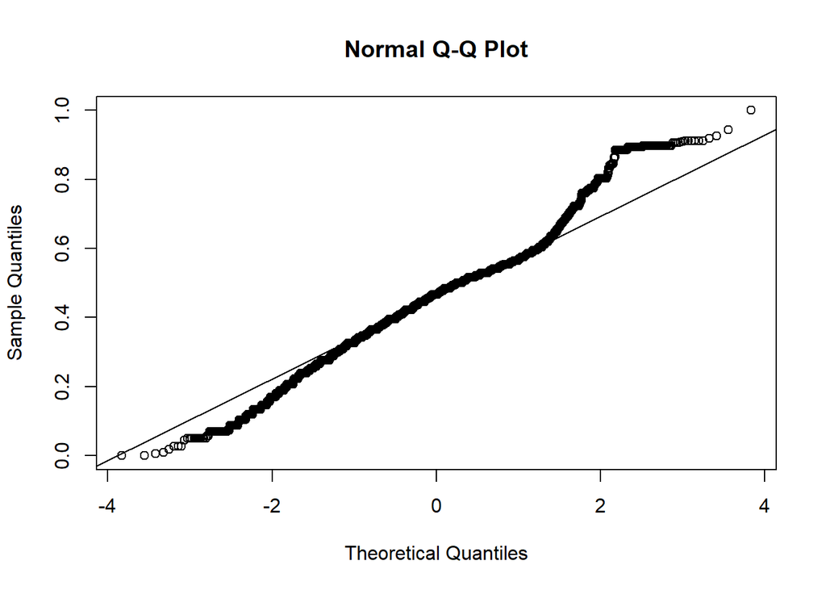

Come possiamo notare dal grafico qqnorm, la densità di selling_price si discosta maggiormente dalla qqline nella parte destra. Questo ci suggerisce che la coda destra della densità della nostra variabile sia più pesante rispetto ad una Normale. Per confermare questa nostra osservazione effettuiamo un analisi della curtosi e della simmetria utlizzando il package moments.

```r
curt <- kurtosis(log(cleanedNA$selling_price))
simm <- skewness(log(cleanedNA$selling_price))

print(paste("Curtosi: ",curt))
```

```
## [1] "Curtosi:  4.09174726540253"
```

```r
print(paste("Simmetria: ",simm))
```

```
## [1] "Simmetria:  0.216131439021605"
```

L’indice K (curtosi) positivo indica una forma più “appuntita” del grafico rispetto ad una Normale; L’indice di Pearson (skewness) leggermente positivo indica una asimmetria verso destra, il grafico infatti sul lato sinistro coincide meglio.

# Analisi Bivariata

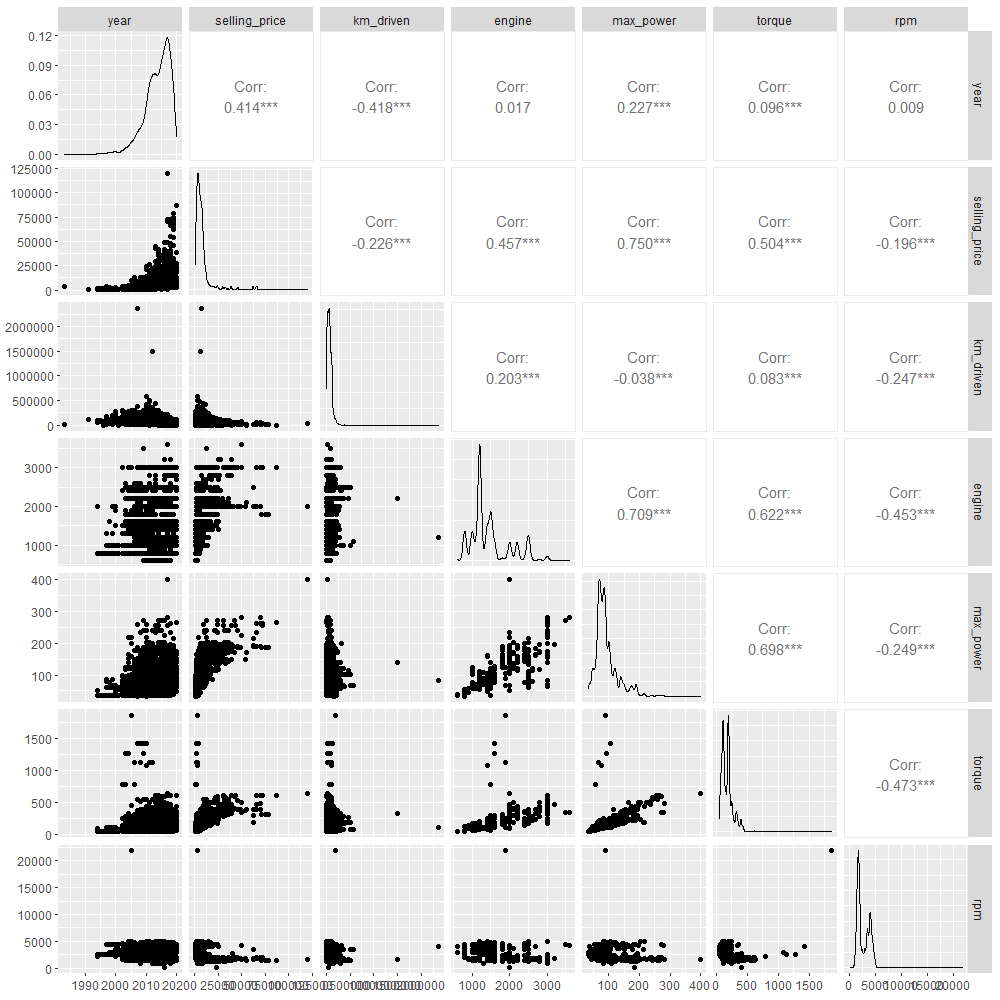

*ggpairs() delle variabili quantitative*

*Il procedimento per il confronto di variabili come “km_driven” o “max_power” ed il modello teorico della normale è il medesimo di quello precedentemente svolto per “selling_price”*.

Notiamo come ci sono correlazioni molto significative (*r>0.5*) che hanno riscontri nella relatà, ad esempio “max_power” e “selling price” (auto potenti tendono a costare di più), oppure “engine” e “torque” (auto con alta cilindrata tendono ad avere molta coppia).

Confrontiamo le distribuzioni per tipologia di carburante:

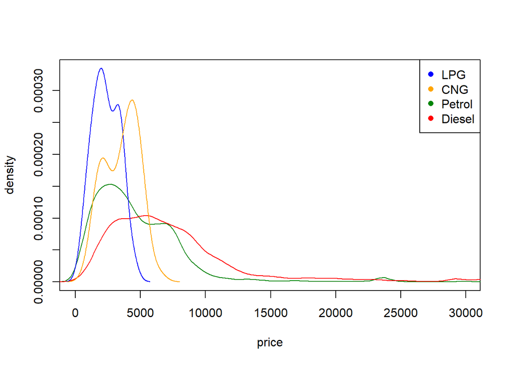

*Il grafico è zoomato sul primo quarto dei dati* notiamo come la maggioranza di auto economiche sia alimentata a GPL o Gas Metano, mentre questi gruppi spariscono superati (rispettivamente) i 6000€ e gli 8000€. Diesel e benzina invece sono presenti in ogni fascia di prezzo.

```
##
##                            Dealer Individual Trustmark Dealer
##   First Owner          90.4085258 60.1241502       86.0169492
##   Second Owner          8.7921847 29.1605084       13.9830508
##   Third Owner           0.3552398  8.1436595        0.0000000
##   Fourth & Above Owner  0.0000000  2.5716819        0.0000000
##   Test Drive Car        0.4440497  0.0000000        0.0000000
```

Dalla tabella di “owner” condizionato a “seller type”, si nota come i concessionari tendano a non vendere auto sopra la terza mano.

```
##
##             First Owner Second Owner Third Owner Fourth & Above Owner
##   Automatic 84.66666667  12.28571429  2.09523810           0.57142857
##   Manual    62.16445324  27.91749082  7.53037581           2.37355185
##
##             Test Drive Car
##   Automatic     0.38095238
##   Manual        0.01412828
```

Le auto automatiche in vendita sono recenti come storico proprietari, ovvero hanno avuto pochi proprietari. “manual” segue lo stesso trend, ma in misura meno marcata.

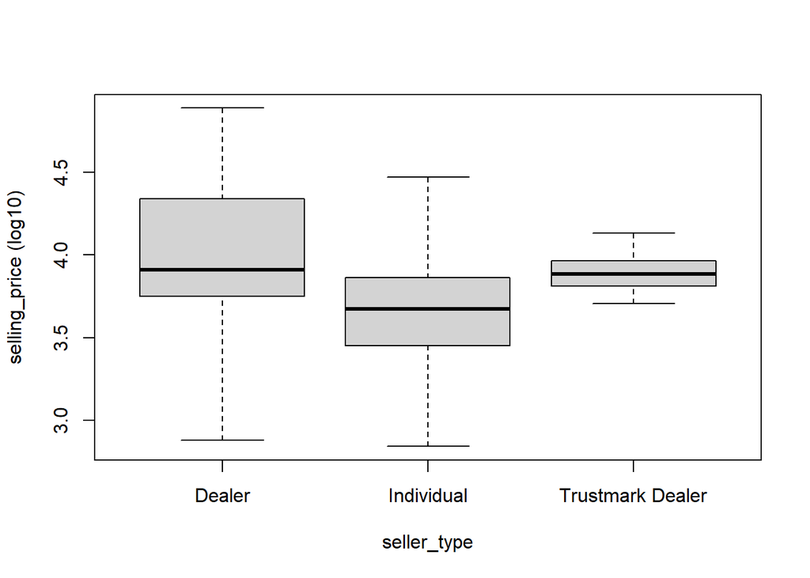

Da questo grafico si evince come le auto in vendita presso i concessionari costino mediamente di più rispetto a quelle vendute dai privati. Persino l’usato “trusted” (cioè affiliato al servizio di vendita) ha un leggero sovrapprezzo rispetto alla vendita individuale.

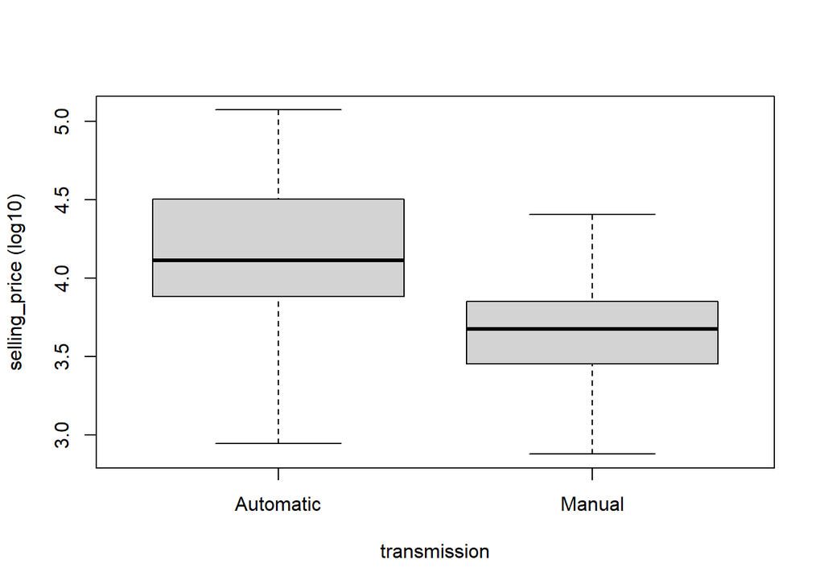

Questo boxplot mostra come le auto automatiche abbiano un prezzo più alto rispetto alle auto manuali.

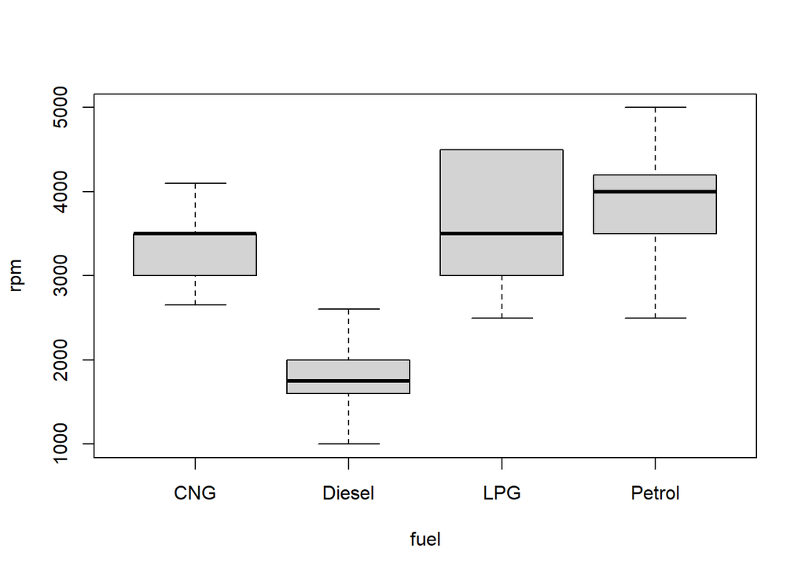

Questo grafico conferma che i motori diesel, data la loro intrinseca caratteristica di essere più pesanti e robusti a causa dell’elevatissima pressione necessaria al funzionamento, abbiano un range di coppia ottimale più basso rispetto alle controparti a gas e benzina, che avendo componenti (pistoni, bielle, volano ecc.) più leggere riescono ad operare a giri più alti.

# Analisi di mercato

#### Quali case automobilistiche sono maggiormente uniformate ai trend di mercato?

Iniziamo osservando lo share di mercato individuale e cumulativo dei vari marchi:

```
##            brand cars       share cumulative_share
## 1         Maruti 2367 30.13367282         30.13367
## 4        Hyundai 1352 17.21196690         47.34564
## 8       Mahindra  756  9.62444303         56.97008
## 9           Tata  718  9.14067473         66.11076
## 3          Honda  466  5.93252705         72.04328
## 5         Toyota  452  5.75429663         77.79758
## 6           Ford  388  4.93952896         82.73711
## 10     Chevrolet  230  2.92807129         85.66518
## 7        Renault  228  2.90260980         88.56779
## 16    Volkswagen  183  2.32972629         90.89752
## 17           BMW  118  1.50222788         92.39975
## 2          Skoda  104  1.32399745         93.72374
## 18        Nissan   81  1.03119032         94.75493
## 20        Jaguar   71  0.90388288         95.65882
```

[output cut: 17 more lines]

Scegliamo di considerare i primi sei marchi in quanti essi costituiscono (cumulativamente) più del 75% del mercato totale, e di analizzare le variabili “engine”, “mileage” e “max_power”.

Lo scopo di questa analisi è verificare l’influenza del brand maggiore sul trend di mercato, e confrontare i primi sei brand con l’andamento generale. Tutti i dati sono ottenuti tramite media mobile semplice (SMA), per il lisciamento delle curve. Dal momento che il primo marchio costituisce il 30% del mercato, ci aspettiamo che i suoi trend siano simili a quelli del mercato totale.

#### Cilindrata

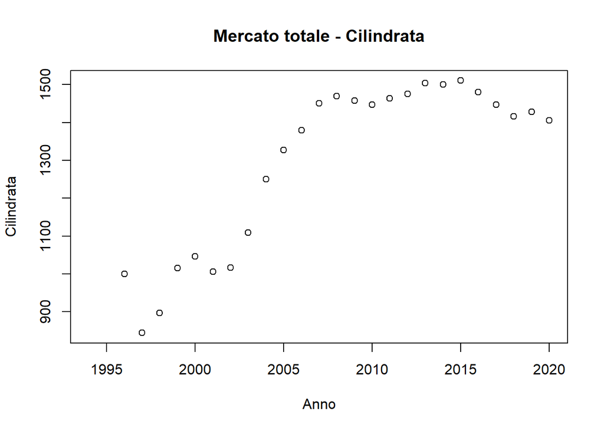

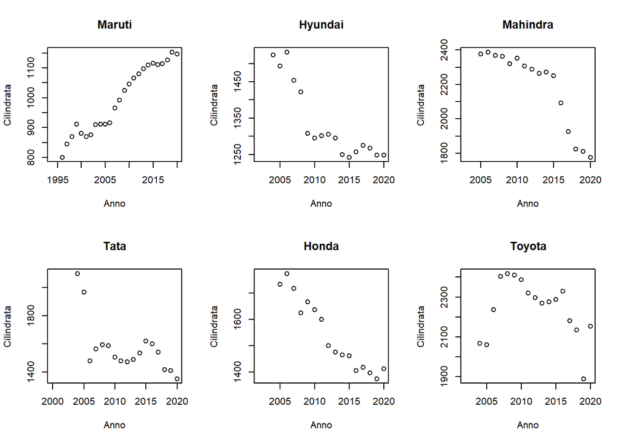

#### Efficienza (Diesel):

*Nota: non sono state considerate, nell’analisi dei consumi, le automobili alimentate a GPL o a Gas Naturale, in quanto non esiste, per marca, un campione statistico sufficiente ad effettuare un’analisi accurata.*

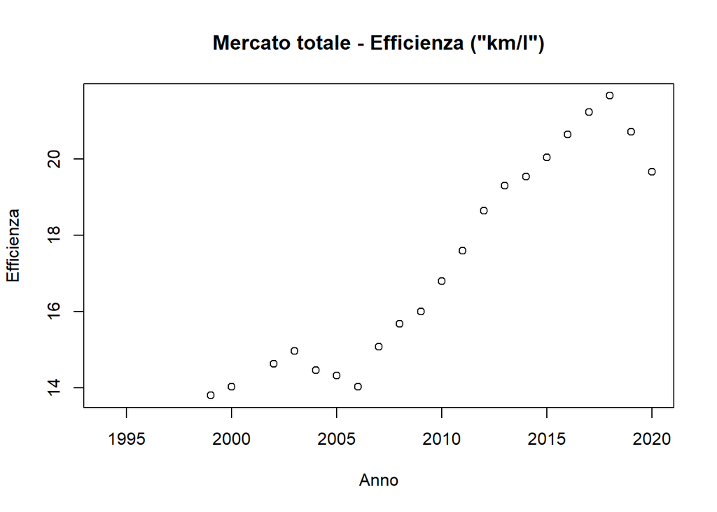

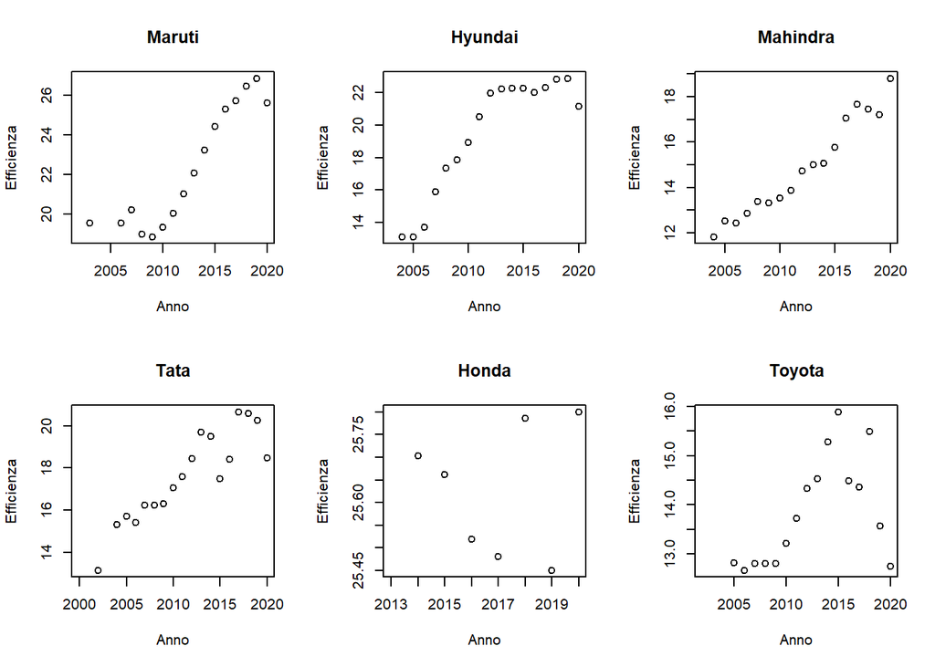

#### Efficienza (Petrol):

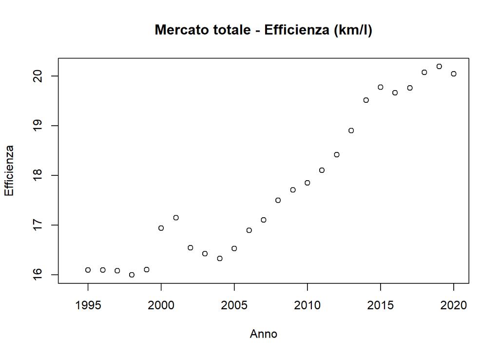

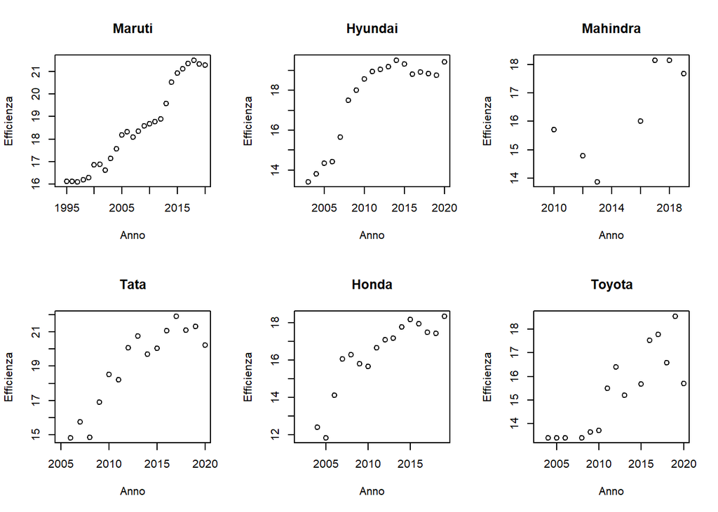

#### Potenza:

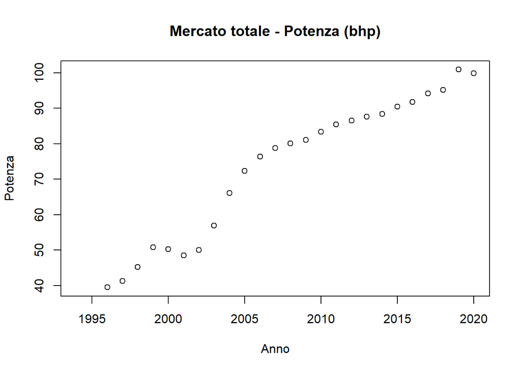

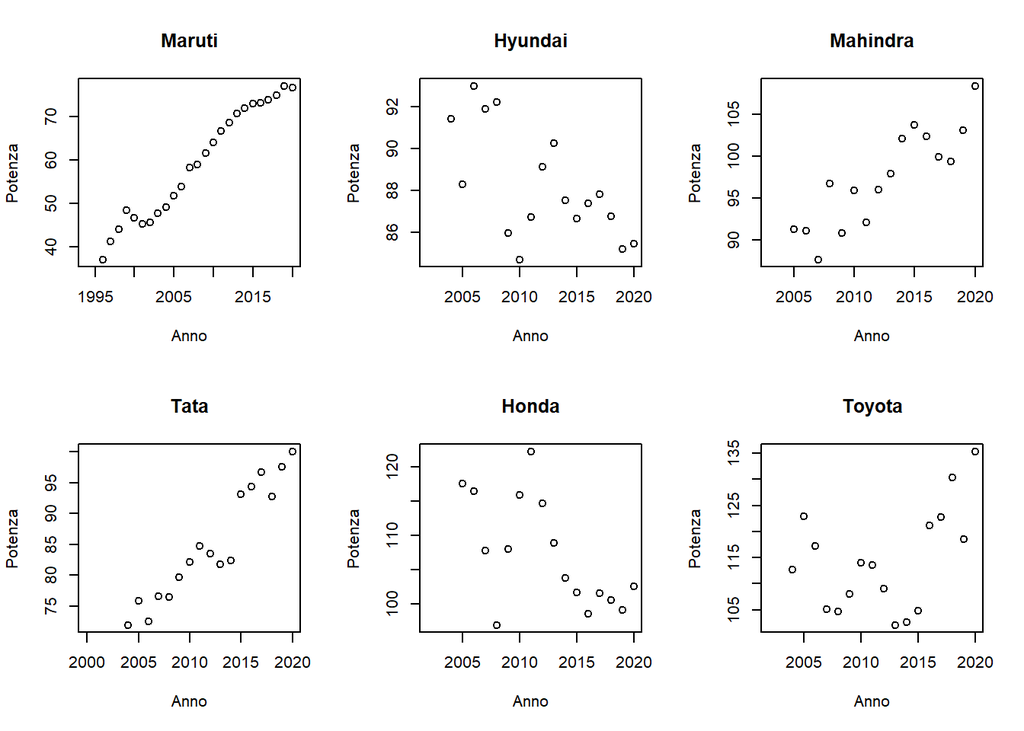

#### Cambio:

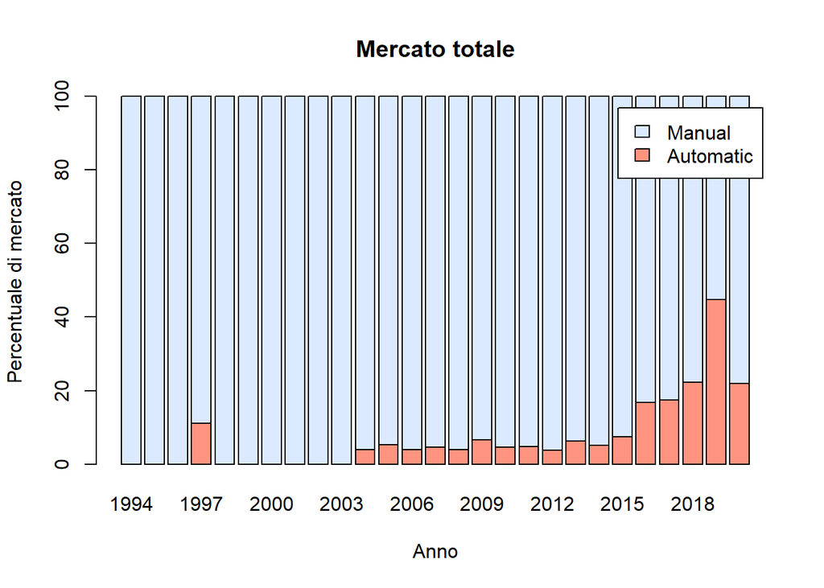

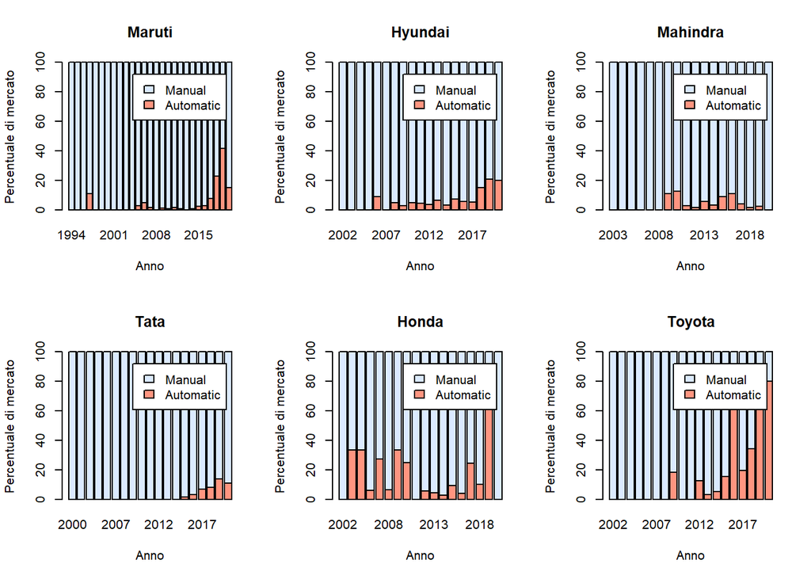

# Modelli lineari

In questa sezione proveremo a creare dei modelli lineari per la previsione di valori futuri, basandoci sui dati esistenti.

#### Modello lineare per “torque”

Proviamo a sviluppare un modello lineare per la coppia:

```
##
## Call:
## lm(formula = torque ~ max_power, data = cleanedNA)
##
## Residuals:
##     Min      1Q  Median      3Q     Max
## -253.39  -39.98    1.59   40.55 1686.76
##
## Coefficients:
##              Estimate Std. Error t value Pr(>|t|)
## (Intercept) -14.28694    2.45683  -5.815 6.29e-09 ***
## max_power     2.12697    0.02514  84.595  < 2e-16 ***
## ---
## Signif. codes:  0 '***' 0.001 '**' 0.01 '*' 0.05 '.' 0.1 ' ' 1
##
## Residual standard error: 78.42 on 7853 degrees of freedom
## Multiple R-squared:  0.4768, Adjusted R-squared:  0.4767
## F-statistic:  7156 on 1 and 7853 DF,  p-value: < 2.2e-16
```

Il p-value è estremamente basso, pertanto la probabilità che la correlazione sia casuale è molto bassa.

Guardiamo quanto il modello sia vicino ai punti:

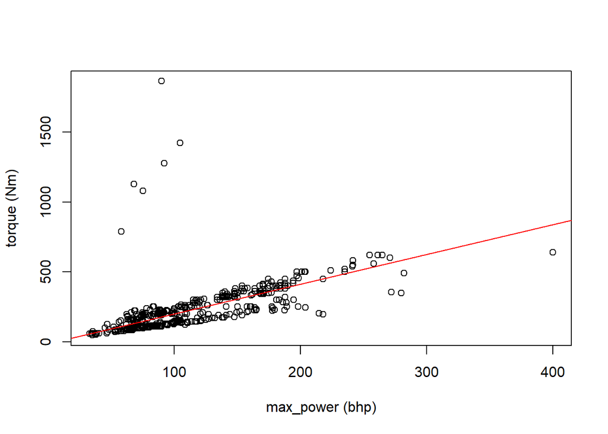

Ora vediamo se possiamo migliorare il modello facendo i test dei residui:

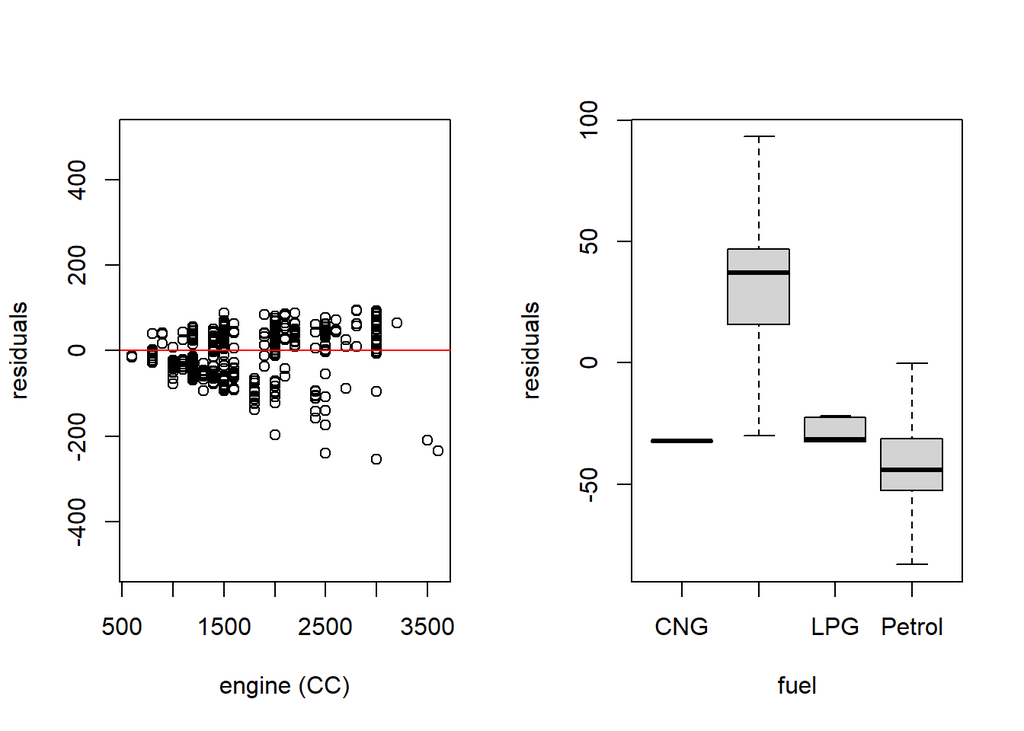

Il modello è migliorabile in quanto gli errori (residui) dipendono dalle variabili “fuel” ed “engine”.

```r
mod2_torque <- lm(data=cleanedNA, torque~max_power+engine+fuel)
summary(mod2_torque)
```

```
##
## Call:
## lm(formula = torque ~ max_power + engine + fuel, data = cleanedNA)
##
## Residuals:
##     Min      1Q  Median      3Q     Max
## -169.29  -10.53   -0.87    7.80 1644.47
##
## Coefficients:
##               Estimate Std. Error t value Pr(>|t|)
## (Intercept) -30.438592   9.537203  -3.192  0.00142 **
## max_power     1.674049   0.030862  54.243  < 2e-16 ***
## engine        0.011057   0.002334   4.738  2.2e-06 ***
## fuelDiesel   78.199255   9.465928   8.261  < 2e-16 ***
## fuelLPG       3.947270  14.741476   0.268  0.78889
## fuelPetrol   -2.386169   9.430760  -0.253  0.80026
## ---
## Signif. codes:  0 '***' 0.001 '**' 0.01 '*' 0.05 '.' 0.1 ' ' 1
##
## Residual standard error: 67.42 on 7849 degrees of freedom
## Multiple R-squared:  0.6135, Adjusted R-squared:  0.6132
## F-statistic:  2492 on 5 and 7849 DF,  p-value: < 2.2e-16
```

#### Proviamo ora a sviluppare un modello per la previsione dei prezzi

```r
mod1_price <- lm(data=cleanedNA, selling_price~max_power)
summary(mod1_price)
```

```
##
## Call:
## lm(formula = selling_price ~ max_power, data = cleanedNA)
##
## Residuals:
##    Min     1Q Median     3Q    Max
## -31172  -2224     50   2162  50644
##
## Coefficients:
##               Estimate Std. Error t value Pr(>|t|)
## (Intercept) -10266.719    195.823  -52.43   <2e-16 ***
## max_power      194.917      2.004   97.26   <2e-16 ***
## ---
## Signif. codes:  0 '***' 0.001 '**' 0.01 '*' 0.05 '.' 0.1 ' ' 1
##
## Residual standard error: 6251 on 7853 degrees of freedom
## Multiple R-squared:  0.5464, Adjusted R-squared:  0.5464
## F-statistic:  9460 on 1 and 7853 DF,  p-value: < 2.2e-16
```

I p-values sono buoni, ma vogliamo ancora migliorare l’r-squared. “selling_price” è influenzato dalla maggior parte delle variabili, prendiamo per esempio i test dei residui effettuati con “torque”, “km_driven”, “brand”, ed “year”.

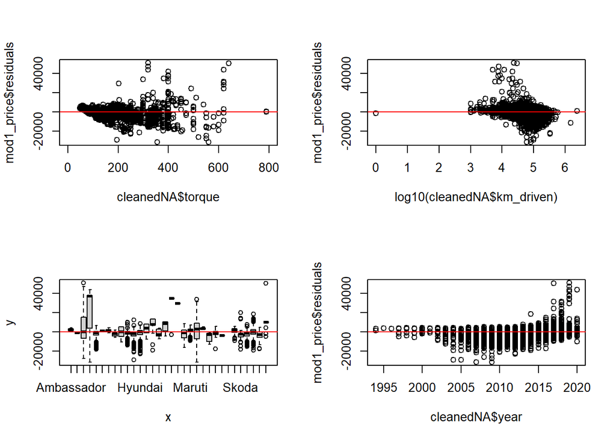

```r
par(mfrow=c(2,2))
plot(cleanedNA$torque, mod1_price$residuals, xlim=range(0, 800))
abline(0, 0, col="red")
plot(log10(cleanedNA$km_driven), mod1_price$residuals)
abline(0, 0, col="red")
plot(cleanedNA$brand, mod1_price$residuals)
abline(0, 0, col="red")
plot(cleanedNA$year, mod1_price$residuals)
abline(0, 0, col="red")
```

Ora generiamo il modello con tutte le variabili:

```r
mod2_price <- lm(selling_price~max_power+year+km_driven+mileage+rpm+brand+transmission+owner+engine+rpm+torque, data=cleanedCSV)
summary(mod2_price)
```

```
##
## Call:
## lm(formula = selling_price ~ max_power + year + km_driven + mileage +
##     rpm + brand + transmission + owner + engine + rpm + torque,
##     data = cleanedCSV)
##
## Residuals:
##    Min     1Q Median     3Q    Max
## -39508  -1249    -93    966  71125
##
## Coefficients:
##                             Estimate Std. Error t value Pr(>|t|)
## (Intercept)               -1.050e+06  3.103e+04 -33.827  < 2e-16 ***
## max_power                  6.889e+01  2.650e+00  25.994  < 2e-16 ***
## year                       5.247e+02  1.550e+01  33.842  < 2e-16 ***
## km_driven                 -7.641e-03  8.608e-04  -8.877  < 2e-16 ***
## mileage                   -3.390e+01  1.750e+01  -1.937 0.052824 .
## rpm                       -4.928e-01  5.320e-02  -9.262  < 2e-16 ***
## brandAshok                -4.211e+03  4.074e+03  -1.034 0.301397
## brandAudi                  7.640e+03  1.939e+03   3.941 8.19e-05 ***
## brandBMW                   2.676e+04  1.881e+03  14.228  < 2e-16 ***
## brandChevrolet            -5.288e+03  1.844e+03  -2.867 0.004151 **
## brandDaewoo                1.128e+03  2.789e+03   0.404 0.685928
## brandDatsun               -5.716e+03  1.888e+03  -3.027 0.002477 **
## brandFiat                 -5.384e+03  1.917e+03  -2.808 0.004992 **
## brandForce                -4.471e+03  2.357e+03  -1.897 0.057903 .
## brandFord                 -4.476e+03  1.839e+03  -2.434 0.014937 *
## brandHonda                -4.280e+03  1.840e+03  -2.326 0.020063 *
## brandHyundai              -4.416e+03  1.834e+03  -2.408 0.016082 *
## brandIsuzu                 2.429e+03  2.454e+03   0.990 0.322332
## brandJaguar                1.295e+04  1.898e+03   6.821 9.68e-12 ***
## brandJeep                  4.228e+03  1.958e+03   2.159 0.030860 *
## brandKia                   4.351e+02  2.587e+03   0.168 0.866426
## brandLand                  2.710e+04  2.459e+03  11.021  < 2e-16 ***
## brandLexus                 3.705e+04  1.966e+03  18.845  < 2e-16 ***
## brandMahindra             -4.666e+03  1.832e+03  -2.548 0.010867 *
## brandMaruti               -3.530e+03  1.832e+03  -1.926 0.054127 .
## brandMercedes-Benz         9.168e+03  1.914e+03   4.790 1.70e-06 ***
## brandMG                    1.487e+03  2.799e+03   0.531 0.595146
## brandMitsubishi           -8.970e+02  2.071e+03  -0.433 0.664863
## brandNissan               -4.756e+03  1.873e+03  -2.539 0.011141 *
## brandOpel                  1.334e+02  4.072e+03   0.033 0.973869
## brandRenault              -4.659e+03  1.848e+03  -2.521 0.011729 *
## brandSkoda                -4.891e+03  1.864e+03  -2.624 0.008712 **
## brandTata                 -5.862e+03  1.834e+03  -3.197 0.001393 **
## brandToyota               -1.053e+03  1.836e+03  -0.574 0.566313
## brandVolkswagen           -5.708e+03  1.850e+03  -3.085 0.002044 **
## brandVolvo                 1.085e+04  1.948e+03   5.570 2.64e-08 ***
## transmissionManual        -1.343e+03  1.671e+02  -8.034 1.08e-15 ***
## ownerSecond Owner         -7.669e+02  1.059e+02  -7.240 4.93e-13 ***
## ownerThird Owner          -4.825e+02  1.827e+02  -2.641 0.008285 **
## ownerFourth & Above Owner -3.666e+02  3.064e+02  -1.197 0.231535
## ownerTest Drive Car        2.891e+04  1.669e+03  17.324  < 2e-16 ***
## engine                     6.851e-01  1.968e-01   3.480 0.000503 ***
## torque                     1.697e+00  6.089e-01   2.787 0.005331 **
## ---
## Signif. codes:  0 '***' 0.001 '**' 0.01 '*' 0.05 '.' 0.1 ' ' 1
##
## Residual standard error: 3639 on 7812 degrees of freedom
##   (273 osservazioni eliminate a causa di valori mancanti)
## Multiple R-squared:  0.8471, Adjusted R-squared:  0.8463
## F-statistic:  1031 on 42 and 7812 DF,  p-value: < 2.2e-16
```

```r
mod3_price <- lm(selling_price~year+max_power+brand, data=cleanedCSV)
summary(mod3_price)$adj.r.squared
```

```
## [1] 0.8415934
```

Osserviamo che questo modello, che determina selling_price partendo da anno, potenza e marca dell’auto ha un coefficente accettabile.

Proviamo dunque a prevedere il prezzo di alcuni modelli dell’anno seguente:

```r
year <- rep(2021, 5)
max_power <- c(70, 98, 120, 82, 100)
brand <- c("Maruti", "BMW", "BMW", "Fiat", "Volvo")
to_predict <- data.frame(year, max_power, brand)
rownames(to_predict) <- paste(brand, max_power, "bhp")
predict(mod3_price, to_predict)
```

```
## Maruti 70 bhp    BMW 98 bhp   BMW 120 bhp   Fiat 82 bhp Volvo 100 bhp
##      9271.761     43075.363     44981.676      8642.363     33690.382
```